# bios731_hw2_linlin

2026-02-07

https://github.com/wull1009/bios731_hw2_linlin

```r
library(here)
```

```r
library(ggplot2)
```

## Problem 1.1 — ADEMP Structure

### A (Aim)

The aim of this simulation study is to evaluate the finite-sample performance of different methods for constructing 95% confidence intervals for the treatment effect $\beta_{\text{treatment}}$ in a multivariable linear regression model. In particular, we compare the Wald confidence interval, the nonparametric bootstrap percentile confidence interval, and the nonparametric bootstrap-$t$ confidence interval under varying sample sizes, true treatment effects, and error distributions.

### D (Data-generating mechanism)

Data are generated from the linear model
$$Y_i = \beta_0 + \beta_{\text{treatment}} X_{i1} + Z_i^\top \gamma +
\epsilon_i,$$
where $X_{i1}$ is a binary treatment indicator and $Z_i$ is a vector of covariates. The simulation varies the following factors in a full factorial design:

- Sample size: $n \in \{10, 50, 500\}$
- True treatment effect: $\beta_{\text{treatment}} \in \{0, 0.5, 2\}$
- Error distribution:
  - Normal errors: $\epsilon_i \sim N(0, 2)$
  - Heavy-tailed errors: $\epsilon_i \sim t_3$, scaled so that $\mathrm{Var}(\epsilon_i)=2$

The treatment indicator $X_{i1}$ and covariates $Z_i$ are generated according to fixed distributions specified in the simulation code.

### E (Estimand)

The estimand of interest is the true regression coefficient $\beta_{\text{treatment}}$, which represents the average treatment effect adjusted for covariates in the linear regression model. Performance is evaluated by comparing the estimated confidence intervals for $\beta_{\text{treatment}}$ to its true value.

### M (Methods)

For each simulated dataset, a multivariable linear regression model is fitted and 95% confidence intervals for $\beta_{\text{treatment}}$ are constructed using three methods:

1. Wald confidence interval, based on the normal approximation:
   $$\hat\beta \pm 1.96 \cdot \widehat{\mathrm{se}}(\hat\beta)$$
2. Nonparametric bootstrap percentile confidence interval, based on the empirical quantiles of $B=500$ bootstrap estimates
3. Nonparametric bootstrap-$t$ confidence interval, using $B=500$ outer bootstrap samples and $B_{\text{inner}}=100$ inner bootstrap samples to estimate the standard error of each bootstrap replicate

### P (Performance measures)

Across repeated simulations for each scenario, the following performance measures are computed:

- Bias: the Monte Carlo average of $\hat\beta_{\text{treatment}} - \beta_{\text{treatment}}$
- Coverage probability: the proportion of 95% confidence intervals that contain the true $\beta_{\text{treatment}}$
- Standard error behavior: empirical distribution of estimated standard errors
- Computation time: average runtime required to construct confidence intervals

### the number for simulation scenarios

we will have 3x3x2 = 18 scenarios.

## Problem 1.2 nSim

We want the Monte Carlo standard error of the estimated coverage (target $\approx 0.95$) to be no more than 1%. Using the lecture formula,
$$SE\big(\widehat{\text{coverage}}\big) \;=\;
\sqrt{\frac{\text{cover}(1-\text{cover})}{n_{\text{sim}}}},$$
we solve:
$$n_{\text{sim}}
\;=\;
\frac{0.95(1-0.95)}{(0.01)^2}
\;=\;
475.$$
Therefore, we will run $n_{\text{sim}}=475$ simulations per scenario.

## Problem 1.3 Implementation

In this homework, we construct 95% confidence intervals for $\beta_{\text{treatment}}$ using: (1) Wald CI, (2) nonparametric bootstrap percentile CI ($B=500$), and (3) nonparametric bootstrap-$t$ CI ($B=500$, $B_{\text{inner}}=100$). We execute the full factorial simulation study and save one `.rds` file per scenario under `data/scenarios/` (ignored by Git).

```r
# source(here("analysis", "run_simulation.R"))
```

since the simulation is large here, we run the simulations on the cluster.

## Problem 1.4 results summary

```r
# This script reads data/scenarios/*.rds and writes:
# - results/summary_table.csv
# - results/bias_by_scenario.png
# - results/coverage_by_scenario.png
# - results/se_distribution.png
# - results/time_by_scenario.png
source(here("analysis", "summarize_results.R"))
```

```
## DONE. Outputs saved in results/: summary_table.csv + 3 PNG plots
```

Summary table (saved to results/summary_table.csv)

```r
# summarize_results.R should create summary_df in the global environment.
knitr::kable(head(summary_df, 12), digits = 4,caption = "Summary table (first 12 rows). Full table saved to results/summary_table.csv.")
```

Summary table (first 12 rows). Full table saved to results/summary_table.csv.

|  | scenario_id | n | beta_treat | error_type | method | bias | coverage | mean_width | mean_time |
| --- | --- | --- | --- | --- | --- | --- | --- | --- | --- |
| 2 | 1 | 10 | 0.0 | normal | boot_percentile | -0.0234 | 0.9515 | 5.8730 | 0.1952 |
| 3 | 1 | 10 | 0.0 | normal | boot_t | -0.0234 | 0.7975 | 3.6026 | 19.1996 |
| 1 | 1 | 10 | 0.0 | normal | wald | -0.0234 | 0.9114 | 4.0514 | 0.0014 |
| 5 | 2 | 50 | 0.0 | normal | boot_percentile | -0.0180 | 0.9305 | 1.5872 | 0.2088 |
| 6 | 2 | 50 | 0.0 | normal | boot_t | -0.0180 | 0.9495 | 1.6814 | 20.5733 |
| 4 | 2 | 50 | 0.0 | normal | wald | -0.0180 | 0.9347 | 1.6111 | 0.0014 |
| 8 | 3 | 500 | 0.0 | normal | boot_percentile | 0.0001 | 0.9663 | 0.4906 | 0.2772 |
| 9 | 3 | 500 | 0.0 | normal | boot_t | 0.0001 | 0.9579 | 0.5008 | 27.8869 |
| 7 | 3 | 500 | 0.0 | normal | wald | 0.0001 | 0.9663 | 0.4967 | 0.0014 |
| 11 | 4 | 10 | 0.5 | normal | boot_percentile | -0.0234 | 0.9515 | 5.8730 | 0.1940 |
| 12 | 4 | 10 | 0.5 | normal | boot_t | -0.0234 | 0.7975 | 3.6026 | 19.0785 |
| 10 | 4 | 10 | 0.5 | normal | wald | -0.0234 | 0.9114 | 4.0514 | 0.0013 |

Plots

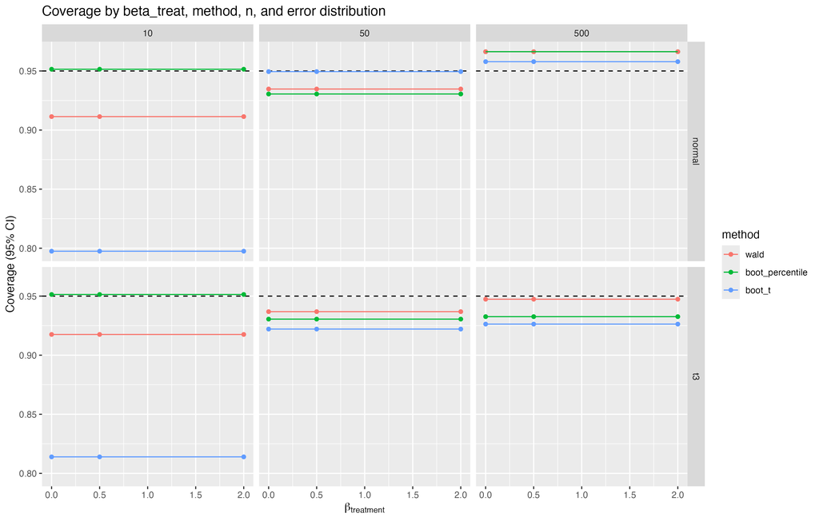

```r
knitr::include_graphics(here("results", "coverage_by_scenario.png"))
```

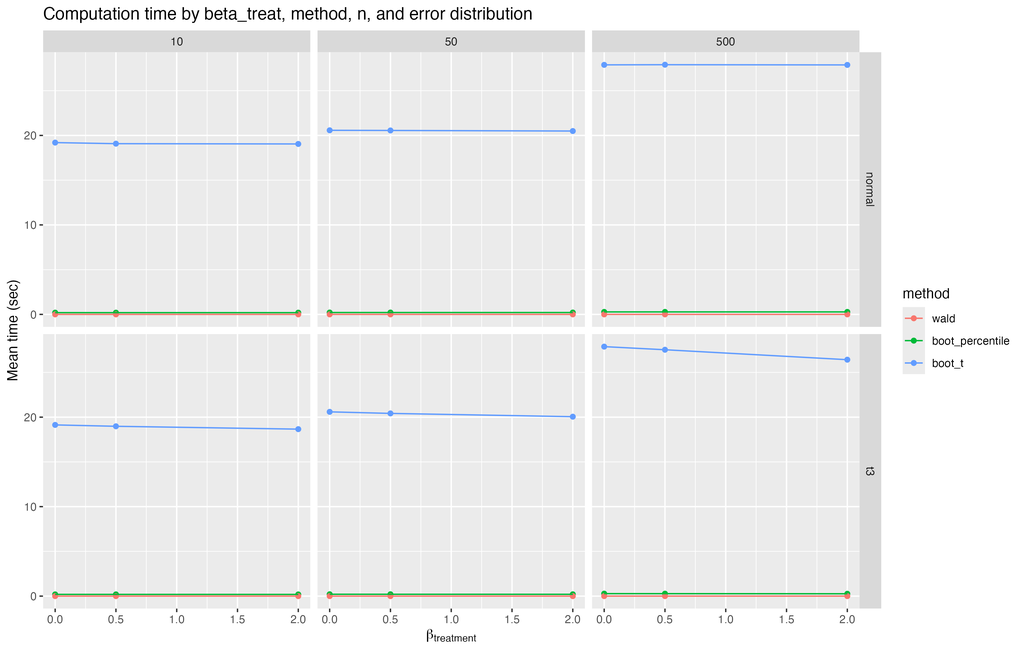

```r
knitr::include_graphics(here("results", "time_by_scenario.png"))
```

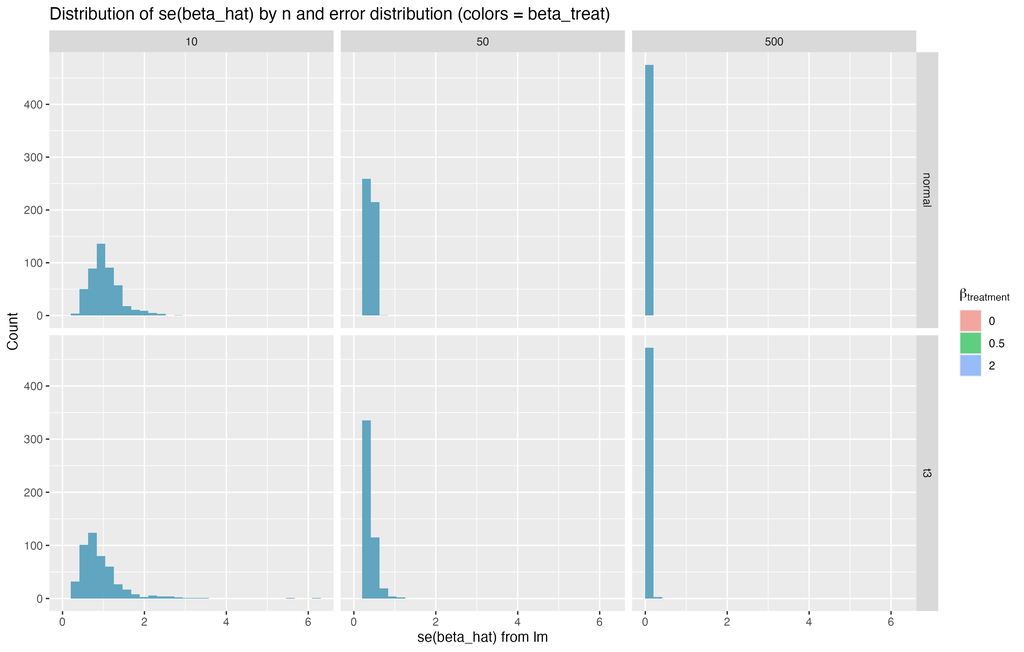

```r
knitr::include_graphics(here("results", "se_distribution.png"))
```